# Pathway analysis: Over-representation analysis (ORA)

CCDL for ALSF

2020

## Objectives

This notebook will demonstrate how to:

- Perform gene identifier conversion with [`AnnotationDBI` annotation packages](https://bioconductor.org/packages/release/bioc/vignettes/AnnotationDbi/inst/doc/IntroToAnnotationPackages.pdf)
- Prepare gene sets for over-representation analysis, including an appropriate background set
- Perform over-representation analysis with the `clusterProfiler` package
- Introduce resources for ORA of scRNA-seq data, such as Gene Ontology

In this notebook, we’ll cover a type of pathway or gene set analysis called over-representation analysis (ORA). The idea behind ORA is relatively straightforward: given a set of genes, do these genes overlap with a pathway more than we expect by chance? The simplicity of only requiring an input gene set (sort of, more on that below) can be attractive.

ORA has some limitations, outlined nicely (and more extensively!) in [Khatri *et al.* (2012)](https://doi.org/10.1371/journal.pcbi.1002375). One of the main issues with ORA is that typically all genes are treated as equal – the context of the magnitude of a change we may be measuring is removed and each gene is treated as independent, which can sometimes result in an incorrect estimate of significance.

We will use the [`clusterProfiler` package](https://bioconductor.org/packages/release/bioc/html/clusterProfiler.html) ([Yu *et al.* 2012](https://doi.org/10.1089/omi.2011.0118.)) to perform ORA. `clusterProfiler` has many built-in functions that will run a specific type of analysis using a specific source of pathways/gene sets automatically, but for our purposes we’re going to keep things as general as possible. See the [`clusterProfiler` book](https://yulab-smu.github.io/clusterProfiler-book/index.html) for more information about the package’s full suite of functionality.

Because different bioinformatics tools often require different types of gene identifiers, we’ll also cover how to convert between gene identifiers using [`AnnotationDbi`](https://bioconductor.org/packages/release/bioc/html/AnnotationDbi.html) Bioconductor packages in this notebook. Check out the [*AnnotationDbi: Introduction To Bioconductor Annotation Packages* (Carlson 2020.) vignette](https://bioconductor.org/packages/release/bioc/vignettes/AnnotationDbi/inst/doc/IntroToAnnotationPackages.pdf) for more information.

#### Other resources

- For another example using `clusterProfiler`, see [*Intro to DGE: Functional Analysis.* from Harvard Chan Bioinformatics Core Training.](https://hbctraining.github.io/DGE_workshop/lessons/09_functional_analysis.html)
- [`WebGestaltR`](https://cran.r-project.org/web/packages/WebGestaltR/) is another R package that can be used for ORA.
- OSCA has [a section on using Gene Ontology sets to annotate clusters](https://bioconductor.org/books/3.14/OSCA.basic/cell-type-annotation.html#assigning-cluster-labels-from-markers) using a different Bioconductor package.

## Set up

### Libraries

```r
# Package we'll use to run ORA
library(clusterProfiler)
# Package that contains MSigDB gene sets in tidy format
library(msigdbr)
# Homo sapiens annotation package we'll use for gene identifier conversion
library(org.Hs.eg.db)
```

### Directories and files

#### Directories

```r
hodgkins_data_dir <- file.path("data", "hodgkins")
# We'll use the output of the clustering notebook for ORA
hodgkins_analysis_dir <- file.path("analysis", "hodgkins")

# We'll create a directory to specifically hold the pathway results
results_dir <- file.path(hodgkins_analysis_dir, "pathway-analysis")
fs::dir_create(results_dir)

# Create a directory for an updated marker list file
fs::dir_create(file.path(hodgkins_analysis_dir, "markers"))
```

#### Input files

We’re going to perform ORA on the marker genes from cluster 1 we looked at in the previous notebook.

```r
input_file <- file.path(hodgkins_data_dir,
                        "markers",
                        "cluster01_markers.tsv")
```

We’re going to use a file that is a cleaned version of the [CellMarker](http://bio-bigdata.hrbmu.edu.cn/CellMarker/) ([Zhang *et al.* 2018](https://doi.org/10.1093/nar/gky900)) human markers resources. You can see how we obtained and cleaned this file in [this notebook](https://github.com/AlexsLemonade/training-modules/blob/master/scRNA-seq/setup/cellmarker_genes.Rmd).

```r
cellmarker_file <- file.path("gene-sets",
                             "CellMarker_cleaned_human_markers.tsv")
```

#### Output files

In the next notebook, we’ll use the cluster 1 results. Saving the post-gene identifier conversion results in this notebook will prevent us from duplicating effort (and code)!

```r
cluster1_output_file <- file.path(hodgkins_analysis_dir,
                                  "markers",
                                  "cluster01_markers_with_gene_symbols.tsv")
```

We’ll save the table of ORA results (e.g., p-values).

```r
go_results_file <- file.path(results_dir, "cluster01_go_ora_results.tsv")
cm_results_file <- file.path(results_dir,
                             "cluster01_CellMarker_ora_results.tsv")
```

## Read in marker genes

Let’s read in our marker genes from cluster 1.

```r
markers_df <- readr::read_tsv(input_file)
```

And let’s take a peek!

```r
head(markers_df)
```

| gene | p.value | FDR | summary.logFC | logFC.2 | logFC.3 | logFC.4 | logFC.5 | logFC.6 | logFC.7 | logFC.8 | logFC.9 | logFC.10 | logFC.11 | logFC.12 | logFC.13 |
| --- | --- | --- | --- | --- | --- | --- | --- | --- | --- | --- | --- | --- | --- | --- | --- |
| ENSG00000153064 | 1.582298e-106 | 1.149381e-102 | 1.9484735 | 1.9508511 | 1.9579572 | 1.950456 | 1.9317035 | 1.9756039 | 1.9756039 | 1.9548115 | 1.9756039 | 1.9524009 | 1.9613336 | 1.9756039 | 1.9484735 |
| ENSG00000247982 | 1.069812e-90 | 3.885559e-87 | 1.3880584 | 1.4078366 | 1.4270666 | 1.389813 | 1.3880584 | 1.4138115 | 1.4221194 | 1.4270666 | 1.4270666 | 1.4139885 | 1.4121868 | 1.4270666 | 1.4270666 |
| ENSG00000211898 | 1.889730e-78 | 4.575666e-75 | 1.7477919 | 1.7639258 | 1.7134065 | 1.737927 | 1.7512171 | 1.7809860 | 1.7796658 | 1.7477919 | 1.7827598 | 1.7512939 | 1.7827598 | 1.7827598 | 1.7525265 |
| ENSG00000163534 | 3.211945e-44 | 5.832892e-41 | 0.8185166 | 0.8555771 | 0.8185166 | 0.847387 | 0.8409975 | 0.8565259 | 0.8562245 | 0.8594033 | 0.8594033 | 0.8594033 | 0.8594033 | 0.8594033 | 0.8594033 |
| ENSG00000177455 | 5.536487e-43 | 8.043408e-40 | 1.0300378 | 1.0527333 | 1.0650058 | 1.050145 | 1.0650058 | 1.0632319 | 1.0626640 | 1.0300378 | 1.0650058 | 1.0650058 | 1.0650058 | 1.0650058 | 1.0650058 |
| ENSG00000224137 | 5.790055e-40 | 7.009827e-37 | 1.2307522 | 1.2454372 | 1.2430434 | 1.257375 | 1.2610217 | 1.2734681 | 1.2736351 | 1.2544495 | 1.2752419 | 1.2307522 | 1.2550414 | 1.2752419 | 1.2752419 |

### Gene identifier conversion

Our data frame of marker genes contains Ensembl gene identifiers. We will need to convert from these identifiers into gene symbols or Entrez IDs for our use with cell marker data.

We’re going to convert our identifiers to gene symbols because they are a bit more human readable, but you can, with the change of a single argument, use the same code to convert to many other types of identifiers!

The annotation package `org.Hs.eg.db` contains information for different identifiers. `org.Hs.eg.db` is specific to *Homo sapiens* – this is what the `Hs` in the package name is referencing. To perform gene identifier conversion in mouse (*Mus musculus*) we could use `org.Mm.eg.db`; we would use `org.Dr.eg.db` for zebrafish (*Danio rerio*).

We can see what types of IDs are available to us in an annotation package with `keytypes()`.

```r
keytypes(org.Hs.eg.db)
```

```
 [1] "ACCNUM"       "ALIAS"        "ENSEMBL"      "ENSEMBLPROT"  "ENSEMBLTRANS"
 [6] "ENTREZID"     "ENZYME"       "EVIDENCE"     "EVIDENCEALL"  "GENENAME"
[11] "GENETYPE"     "GO"           "GOALL"        "IPI"          "MAP"
[16] "OMIM"         "ONTOLOGY"     "ONTOLOGYALL"  "PATH"         "PFAM"
[21] "PMID"         "PROSITE"      "REFSEQ"       "SYMBOL"       "UCSCKG"
[26] "UNIPROT"
```

[output not shown]

Even though we’ll use this package to convert from Ensembl gene IDs (`ENSEMBL`) to gene symbols (`SYMBOL`), we could just as easily use it to convert from an Ensembl transcript ID (`ENSEMBLTRANS`) to Entrez IDs (`ENTREZID`).

The function we will use to map from Ensembl gene IDs to gene symbols is called `mapIds()`.

```r
# This returns a named vector which we can convert to a data frame, where
# the keys (Ensembl IDs) are the names
symbols_vector <- mapIds(org.Hs.eg.db,  # Specify the annotation package
                         # The vector of gene identifiers we want to
                         # map
                         keys = markers_df$gene,
                         # What type of gene identifiers we're starting
                         # with
                         keytype = "ENSEMBL",
                         # The type of gene identifier we want returned
                         column = "SYMBOL",
                         # In the case of 1:many mappings, return the
                         # first one. This is default behavior!
                         multiVals = "first")
# We would like a data frame we can join to the DGE results
symbols_df <- data.frame(
  ensembl_id = names(symbols_vector),
  gene_symbol = symbols_vector
) |>
  # Drop genes that don't have a gene symbol!
  tidyr::drop_na()
```

Now we are ready to add the gene symbols to our data frame with the marker genes. We can use a *join* function from the `dplyr` package to do this, which will use the Ensembl gene IDs in both data frames to determine how to join the rows.

```r
markers_df <- symbols_df |>
  # An *inner* join will only return rows that are in both data frames
  dplyr::inner_join(markers_df,
                    # The name of the column that contains the Ensembl gene IDs
                    # in the left data frame and right data frame, effectively
                    # dropping genes that don't have gene symbols
                    by = c("ensembl_id" = "gene"))
```

We’re going to use this table again, with the gene symbols, in the next notebook so let’s write it to a file.

```r
readr::write_tsv(markers_df, file = cluster1_output_file)
```

## Over-representation Analysis (ORA)

To test for over-representation, we can calculate a p-value with a hypergeometric test ([ref](https://yulab-smu.github.io/clusterProfiler-book/chapter2.html#over-representation-analysis)).

$p = 1 - \displaystyle\sum_{i = 0}^{k-1}\frac{ {M \choose i}{ {N-M} \choose {n-i} } } { {N \choose n} }$

Where `N` is the number of genes in the background distribution, `M` is the number of genes in a pathway or gene set, `n` is the number of genes we are interested in (our marker genes), and `k` is the number of genes that overlap between the pathway or gene set and our marker genes.

Borrowing an example from [*clusterProfiler: universal enrichment tool for functional and comparative study* (Yu )](http://yulab-smu.top/clusterProfiler-book/chapter2.html#over-representation-analysis):

> **Example**: Suppose we have 17,980 genes detected in a Microarray study and 57 genes were differentially expressed. Among the differential expressed genes, 28 are annotated to a gene set.

We’ll call genes that are differentially expressed `gene_in_interest` and genes that are in the gene set `in_gene_set`.

```r
gene_table <- data.frame(
  gene_not_interest = c(2613, 15310),
  gene_in_interest = c(28, 29)
)
rownames(gene_table) <- c("in_gene_set", "not_in_gene_set")

gene_table
```

|  | gene_not_interest | gene_in_interest |
| --- | --- | --- |
| in_gene_set | 2613 | 28 |
| not_in_gene_set | 15310 | 29 |

We can assess if the 28 overlapping genes mean that the differentially expressed genes are over-represented in the gene set with the hypergeometric distribution. This corresponds to a one-sided Fisher’s exact test.

```r
fisher.test(gene_table, alternative = "greater")
```

```
    Fisher's Exact Test for Count Data

data:  gene_table
p-value = 1
alternative hypothesis: true odds ratio is greater than 1
95 percent confidence interval:
 0.110242      Inf
sample estimates:
odds ratio
 0.1767937
```

When we test **multiple pathways or gene sets**, the p-values then need to be **adjusted** for multiple hypothesis testing.

### Marker gene preparation

#### Top 100 cluster 1 genes

We’re interested in what pathways are over-represented in genes that mark, or are more highly expressed in, cluster 1. We’ll select the top 100 genes for this comparison.

```r
cluster01_markers <- markers_df |>
  # Positive fold changes
  dplyr::filter(summary.logFC > 0) |>
  # Take the "top 100" when ordering by FDR (smallest FDR values)
  dplyr::slice_min(order_by = FDR, n = 100) |>
  # Extract a vector of the gene symbols
  dplyr::pull(gene_symbol)
```

You may think that selecting the top 100 genes is pretty arbitrary and you are not wrong! This also may seem strict, but let’s think about our goal for this particular analysis: we hope that using ORA with resources that encode some knowledge about cell types will help us annotate cluster 1. We’re using the very top ranked genes in service of this goal.

An alternative approach would be to have filtered to genes that are below a specific FDR threshold, but that would also be an arbitrary threshold that we chose. This is a weakness of over-representation analysis; we generally need to pick a threshold for the genes that we include in our tests.

As we mentioned in the clustering notebook, our statistical calculations are circular here. We identified clusters based on gene expression and then identified genes that are differentially expressed between clusters. We can use the FDR values for ranking, like we are here, but we shouldn’t use them to define “significance.” You can read a little more about this in the [*Invalidity of p-values* section of the OSCA book](https://bioconductor.org/books/3.14/OSCA.advanced/marker-detection-redux.html#p-value-invalidity).

#### Background set

As we saw above, calculating the p-value for ORA relies on the number of genes in the background distribution. Sometimes folks consider genes from the entire genome to comprise the background, but in the example borrowed from the `clusterProfiler` authors, they state:

> 17,980 genes detected in a Microarray study

Where the key phrase is **genes detected**.

If we were unable to include a gene in our marker gene comparisons because, for example, we could not reliably measure it, we shouldn’t include in our background set!

Our markers data frame has all of the genes that we did not filter out and have gene symbols corresponding to the Ensembl gene IDs, so we can use the `gene_symbol` column as our background set.

```r
background_set <- markers_df$gene_symbol
```

### Gene Ontology ORA

#### A note on GO

The Gene Ontology (GO) ([Ashburner *et al.* 2000](https://dx.doi.org/10.1038/75556); [The Gene Ontology Consortium. 2021](https://doi.org/10.1093/nar/gkaa1113))is an ontology that documents or describes how genes function in the biological domain and is comprised of 3 parts ([GO ontology documentation](http://geneontology.org/docs/ontology-documentation/)):

- **Molecular function (MF):** activities that occur on the molecular level, often can be performed by individual genes
- **Biological process (BP):** programs carried out by multiple molecular entities; similar to what is sometimes thought of as a pathway, but with no notion of *dynamics*
- **Cellular component (CC):** cellular structures and compartments

GO is “loosely hierarchical” ([GO ontology documentation](http://geneontology.org/docs/ontology-documentation/)). There are parent and child terms, where the “higher up” a term is, the more general it is. This is somewhat abstract, so let’s take a look at a GO term that’s likely to be relevant to our Hodgkin’s lymphoma data to get an idea of what this is like in practice: [`leukocyte activation`](http://www.informatics.jax.org/vocab/gene_ontology/GO:0045321).

#### Run `enrichGO()`

Now that we have our background set and our genes of interest, we’re ready to run ORA using the `enrichGO()` function.

```r
go_ora_results <- enrichGO(gene = cluster01_markers,  # Top 100 genes
                           universe = background_set,  # Background genes
                           keyType = "SYMBOL",  # Our genes are gene symbols
                           OrgDb = org.Hs.eg.db,  # Supports conversion, if needed
                           ont = "BP",  # Biological process
                           pAdjustMethod = "BH",  # FDR
                           pvalueCutoff = 0.00001) # Very stringent for viz
```

What is returned by `enrichGO()`?

```r
View(go_ora_results)
```

The information we’re most likely interested in is in the `result` slot. Let’s convert this into a data frame that we can write to file.

```r
go_result_df <- data.frame(go_ora_results@result)
```

Let’s take a look at the GO sets with an adjusted p-value less than 0.00001.

```r
go_result_df |>
  dplyr::filter(p.adjust < 0.00001)
```

|  | ID | Description | GeneRatio | BgRatio | pvalue | p.adjust | qvalue | geneID | Count |
| --- | --- | --- | --- | --- | --- | --- | --- | --- | --- |
| GO:0050853 | GO:0050853 | B cell receptor signaling pathway | 14/91 | 53/6658 | 4.411536e-15 | 7.684895e-12 | 7.290643e-12 | BANK1/IGHD/CD19/MS4A1/CD79A/IGHM/IGLC3/CD22/CD79B/FCMR/MEF2C/BLK/LAT2/BCL2 | 14 |
| GO:0050851 | GO:0050851 | antigen receptor-mediated signaling pathway | 17/91 | 152/6658 | 1.366021e-11 | 1.189805e-08 | 1.128765e-08 | BANK1/IGHD/CD19/MS4A1/CD79A/IGHM/IGLC3/CD22/CD79B/LAPTM5/FCMR/ELF1/TRBC2/MEF2C/BLK/LAT2/BCL2 | 17 |
| GO:0002768 | GO:0002768 | immune response-regulating cell surface receptor signaling pathway | 18/91 | 221/6658 | 6.616509e-10 | 3.841986e-07 | 3.644884e-07 | BANK1/IGHD/CD19/MS4A1/CD79A/FCER2/IGHM/IGLC3/CD22/CD79B/LAPTM5/FCMR/ELF1/TRBC2/MEF2C/BLK/LAT2/BCL2 | 18 |
| GO:0002429 | GO:0002429 | immune response-activating cell surface receptor signaling pathway | 17/91 | 210/6658 | 2.318298e-09 | 1.009619e-06 | 9.578230e-07 | BANK1/IGHD/CD19/MS4A1/CD79A/IGHM/IGLC3/CD22/CD79B/LAPTM5/FCMR/ELF1/TRBC2/MEF2C/BLK/LAT2/BCL2 | 17 |
| GO:0006959 | GO:0006959 | humoral immune response | 11/91 | 75/6658 | 4.019570e-09 | 1.400418e-06 | 1.328574e-06 | POU2AF1/MS4A1/FCER2/IGHM/ST6GAL1/FCMR/POU2F2/CD83/JCHAIN/MEF2C/BCL2 | 11 |
| GO:0042113 | GO:0042113 | B cell activation | 15/91 | 183/6658 | 1.920120e-08 | 5.574749e-06 | 5.288752e-06 | BANK1/FCRL1/CD19/POU2AF1/TNFRSF13C/PAX5/MS4A1/CD79A/CD22/CD79B/LAPTM5/MEF2C/TPD52/LAT2/BCL2 | 15 |

Some of these columns have names that are somewhat opaque and are used for visualization, so let’s briefly talk about them here!

| Column name | Numerator | Denominator |
| --- | --- | --- |
| `GeneRatio` | Number of genes in the top 100 marker genes and the specific gene set (also in `Count` column) | Number of genes in the top 100 marker genes and *any* gene set |
| `BgRatio` | Number of genes in the background set and the specific gene set | Number of genes in the background set and *any* gene set |

#### Visualizing results

We can use a dot plot to visualize our significant enrichment results.

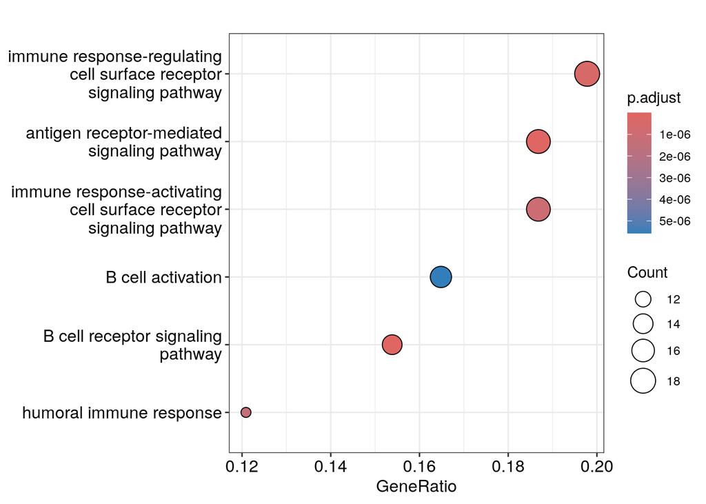

```r
enrichplot::dotplot(go_ora_results)
```

**What cell type do you think the cells from cluster 1 are?**

We can use an [UpSet plot](https://www.ncbi.nlm.nih.gov/pmc/articles/PMC4720993/) to visualize the **overlap** between the gene sets that were returned as significant.

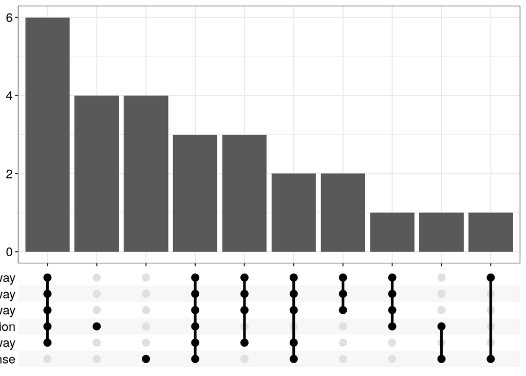

```r
enrichplot::upsetplot(go_ora_results)
```

It’s important to keep in mind that gene sets or pathways aren’t independent, either! This is particularly true of GO terms, which are hierarchical in nature.

### CellMarker ORA

Next, we’ll use another resource, CellMarker, as additional support for our conclusions based on GO.

#### About CellMarker

[CellMarker](http://bio-bigdata.hrbmu.edu.cn/CellMarker/) is a manually curated database of cell marker data for human and mouse ([Zhang *et al.* 2018](https://doi.org/10.1093/nar/gky900)). Studies/evidence of the following nature were included in the manual curation process ([Zhang *et al.* 2018](https://doi.org/10.1093/nar/gky900)):

- scRNA-seq
- Flow cytometry
- Immunostaining

And there are both gene and protein markers.

Let’s read in the CellMarker data we’ve already cleaned:

```r
cellmarker_df <- readr::read_tsv(cellmarker_file)
```

#### Run `enricher()`

`clusterProfiler::enricher()` is a more general way to perform ORA – we specify the pathways or gene sets ourselves. We can use the it to run ORA with the CellMarker data, which contains gene symbols. That’s why we needed to perform gene identifier conversion earlier!

```r
cellmarker_ora_results <- enricher(
  gene = cluster01_markers,  # Genes of interest
  pvalueCutoff = 0.05,  # More permissive cut off
  pAdjustMethod = "BH",  # FDR
  universe = background_set,  # Background set
  # The pathway information should be a data frame with a term name or
  # identifier and the gene identifiers
  TERM2GENE = cellmarker_df
)
```

#### Visualizing results

Let’s look at a bar plot of the significant results.

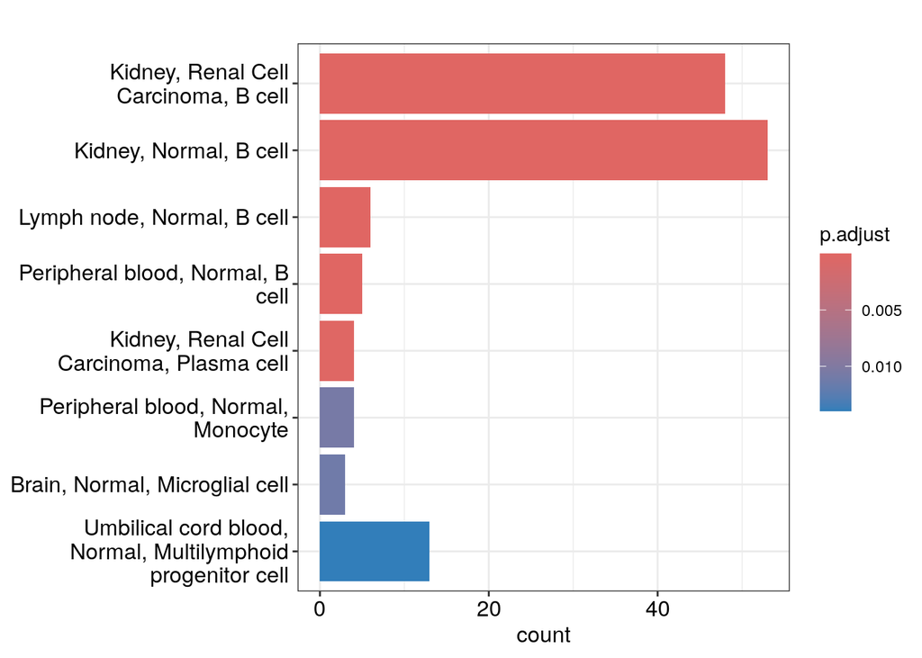

```r
barplot(cellmarker_ora_results) +
  # This is a ggplot, so we can use the following to label the x-axis!
  ggplot2::labs(x = "count")
```

One thing that the [web version of CellMarker](http://bio-bigdata.hrbmu.edu.cn/CellMarker/) allows us to do is to get a better idea of *marker prevalence*. Some of the genes that show up in our top 100 may not be very specific. It’s also likely that kidney is not very relevant to our analysis of Hodgkin’s lymphoma, but lymph node is highly relevant. However, blood cells in kidney are not *unexpected* and, if we view the [CellMarker tissue type browser](http://bio-bigdata.hrbmu.edu.cn/CellMarker/browse.jsp), we can see that there are *a lot* of genes annotated to kidney. Every resource will have some limitations “baked in.”

We could do additional filtering of the gene sets to remove irrelevant tissues and to remove marker genes that are not particularly specific. (Fewer gene sets would mean a lower multiple hypothesis testing burden.) If some of the CellMarker marker genes come from immunostaining of terminally differentiated cells, we might not expect their transcripts to show up in scRNA-seq data, for example. All things to keep in mind if you use this resource for your own work!

### Write results to file

Write the results to file for both GO and CellMarker gene sets.

```r
readr::write_tsv(go_result_df, file = go_results_file)
data.frame(cellmarker_ora_results@result) |>
  readr::write_tsv(file = cm_results_file)
```

## Parting thoughts

The goal of analyzing marker genes with ORA, like we did in this notebook, is to help us interpret our clustering results or annotate clusters. We shouldn’t use marker genes or any downstream analysis we perform with them to *justify* cluster assignments; we generally want our cluster assignments to be data-driven.

Just like it’s important to be skeptical about p-values returned from the marker gene analysis itself, we should not get too attached to the idea of statistical significance here. If we were to tweak the cutoffs (e.g., take the top 2500 genes), we might expect to get completely different significant results. This is a limitation of ORA: we have to make some choices that are somewhat arbitrary. It’s a good idea to think about the goal of your analysis *upfront* and pick cutoffs based on your goals. That can help you avoid the temptation of trying a bunch of cutoffs until you get results that “look good.”